# My document

#### ndi

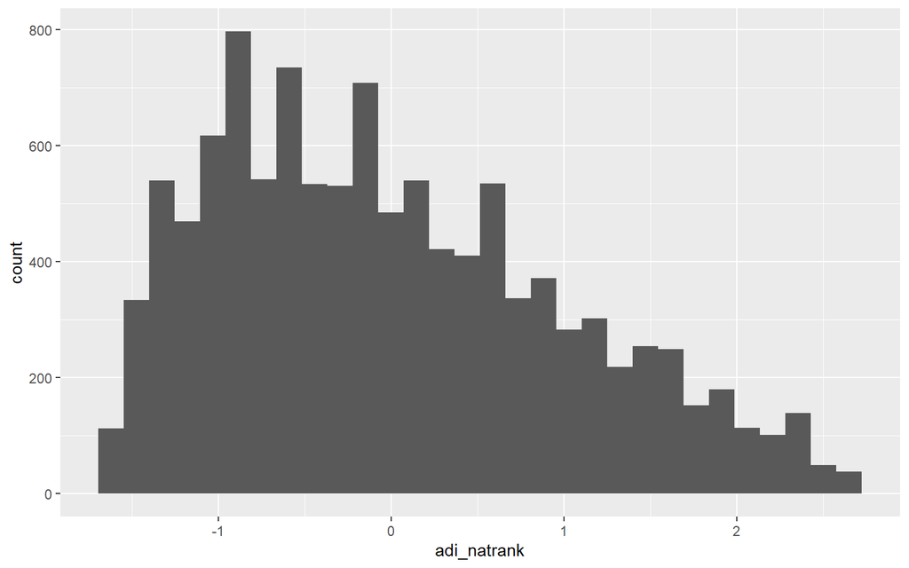

```r
ggplot(data=under.df, aes(x = adi_natrank)) +
  geom_histogram()
```

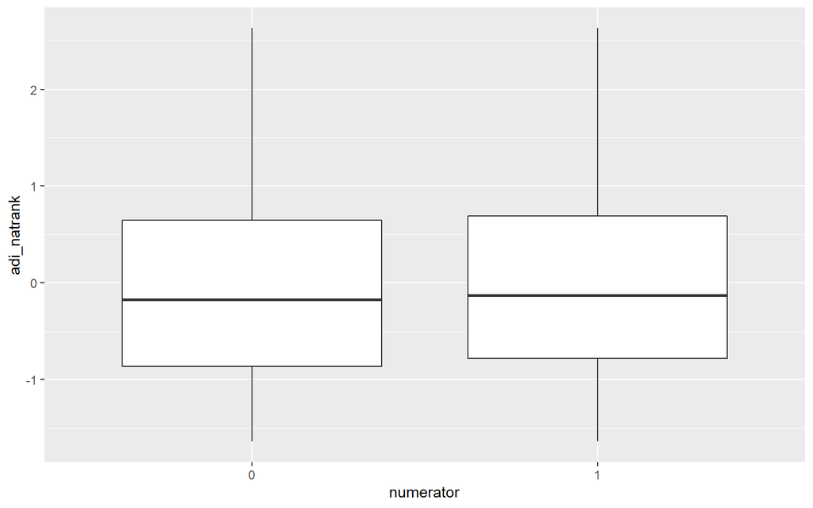

```r
ggplot(data=under.df, aes(x = numerator, y = adi_natrank)) +
  geom_boxplot()
```

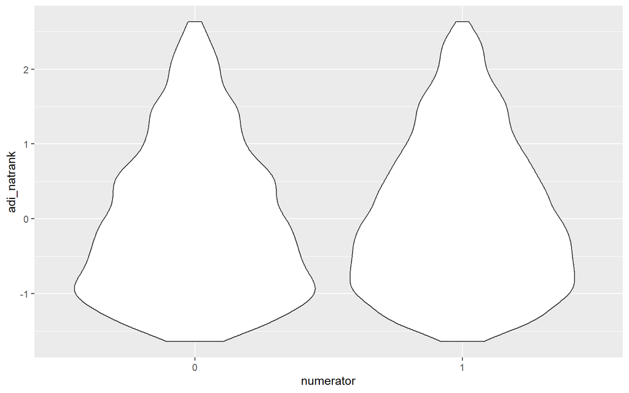

```r
ggplot(data=under.df, aes(x = numerator, y = adi_natrank)) +
  geom_violin()
```

```r
ndi_summary <- under.df %>%
  group_by(numerator) %>%
  summarize(n = n(),
         mean = mean(adi_natrank,na.rm=TRUE),
         median = median(adi_natrank,na.rm=TRUE),
         sd = sd(adi_natrank,na.rm=TRUE)
         )
ndi_summary
```

```
## # A tibble: 2 x 5
##   numerator     n    mean median    sd
##   <fct>     <int>   <dbl>  <dbl> <dbl>
## 1 0          5967 -0.0356 -0.174 1.00
## 2 1          8791  0.0239 -0.130 0.996
```

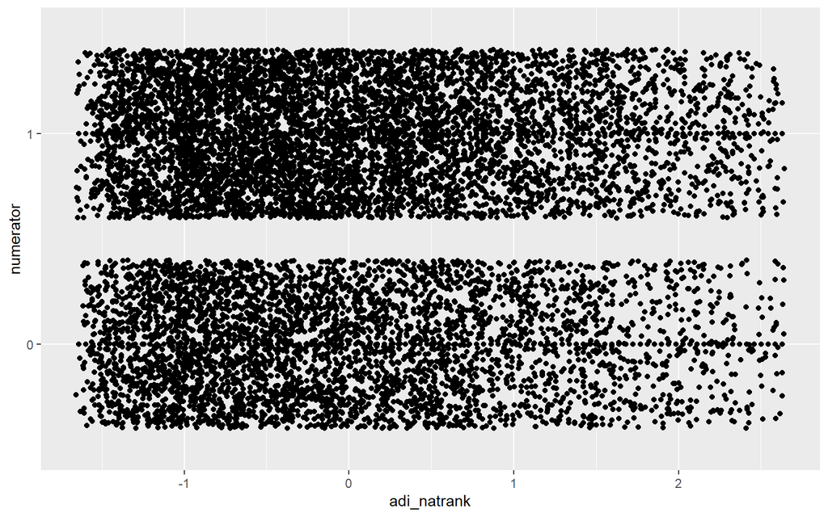

```r
ggplot(data = under.df, aes(x =adi_natrank, y =numerator)) +
  geom_point() +
  geom_jitter()
```

### regression

#### method 1 - PQL (penalized quasi likelihood)

```r
mU.pql <- glmmPQL(numerator ~ predicted_race +
                    gender +
                    age +
                    adi_natrank,
                random=list(member_number = ~1, ebm_measure_label = ~1),
                family = "binomial",
                data = under.df)
```

[output not shown]

[output not shown]

[output not shown]

[output not shown]

[output not shown]

[output not shown]

[output not shown]

[output not shown]

[output not shown]

[output not shown]

```r
summary(mU.pql)
```

```
## Linear mixed-effects model fit by maximum likelihood
##   Data: under.df
##   AIC BIC logLik
##    NA  NA     NA
##
## Random effects:
##  Formula: ~1 | member_number
##          (Intercept)
## StdDev: 6.971145e-07
##
##  Formula: ~1 | ebm_measure_label %in% member_number
##         (Intercept)     Residual
## StdDev:    10.03202 3.043584e-14
##
## Variance function:
##  Structure: fixed weights
##  Formula: ~invwt
## Fixed effects:  numerator ~ predicted_race + gender + age + adi_natrank
##                             Value Std.Error   DF   t-value p-value
## (Intercept)              1.409591  0.132866 9132 10.609099  0.0000
## predicted_race2prace   -22.958645  7.098465 9132 -3.234311  0.0012
## predicted_raceaian      -3.614615  3.030595 9132 -1.192708  0.2330
## predicted_raceapi        0.495197  0.478762 9132  1.034327  0.3010
## predicted_raceblack     -0.771868  0.362079 9132 -2.131768  0.0331
## predicted_racehispanic  -0.759179  0.376701 9132 -2.015336  0.0439
## genderMALE               2.050813  0.195891 9132 10.469147  0.0000
## genderUNKNOWN           19.618948  7.098650 9132  2.763758  0.0057
## age                      0.934224  0.096385 9132  9.692668  0.0000
## adi_natrank              0.381911  0.101218 9132  3.773158  0.0002
##  Correlation:
##                        (Intr) prdc_2 prdctd_rcn prdctd_rcp prdctd_rcb
## predicted_race2prace   -0.010
## predicted_raceaian     -0.031  0.001
## predicted_raceapi      -0.157  0.004  0.003
## predicted_raceblack    -0.278  0.004  0.022      0.032
## predicted_racehispanic -0.226  0.004  0.014      0.053      0.110
## genderMALE             -0.596 -0.004  0.000     -0.022      0.040
## genderUNKNOWN          -0.019  0.000  0.000      0.003      0.004
## age                     0.044  0.014  0.003      0.054     -0.012
## adi_natrank             0.024  0.000 -0.041      0.104     -0.276
##                        prdctd_rch gnMALE gUNKNO age
## predicted_race2prace
## predicted_raceaian
## predicted_raceapi
## predicted_raceblack
## predicted_racehispanic
## genderMALE             -0.011
## genderUNKNOWN           0.003      0.012
## age                     0.025     -0.088 -0.011
## adi_natrank            -0.100      0.072  0.005 -0.103
##
## Standardized Within-Group Residuals:
##          Min           Q1          Med           Q3          Max
## -0.001757267  0.000000000  0.000000000  0.000000000  0.001757084
##
## Number of Observations: 11103
## Number of Groups:
##                        member_number ebm_measure_label %in% member_number
##                                 9142                                11103
```

#### method 2 - glmer

```r
mU.glmer <- glmer(numerator ~  predicted_race +
                    gender +
                    age +
                    adi_natrank +
                    (1|member_number) +
                    (1|ebm_measure_label),
                family = binomial(link="logit"),
                data = under.df,
                control=glmerControl(optimizer="bobyqa",optCtrl=list(maxfun=2e5)))
summary(mU.glmer)
```

```
## Generalized linear mixed model fit by maximum likelihood (Laplace
##   Approximation) [glmerMod]
##  Family: binomial  ( logit )
## Formula: numerator ~ predicted_race + gender + age + adi_natrank + (1 |
##     member_number) + (1 | ebm_measure_label)
##    Data: under.df
## Control: glmerControl(optimizer = "bobyqa", optCtrl = list(maxfun = 2e+05))
##
##      AIC      BIC   logLik deviance df.resid
##  13108.6  13196.3  -6542.3  13084.6    11091
##
## Scaled residuals:
##     Min      1Q  Median      3Q     Max
## -2.6792 -0.7306  0.4972  0.6344  3.1991
##
## Random effects:
##  Groups            Name        Variance Std.Dev.
##  member_number     (Intercept) 0.2444   0.4944
##  ebm_measure_label (Intercept) 1.1869   1.0894
## Number of obs: 11103, groups:  member_number, 9142; ebm_measure_label, 11
##
## Fixed effects:
##                          Estimate Std. Error z value Pr(>|z|)
## (Intercept)             -0.146688   0.331767  -0.442 0.658386
## predicted_race2prace   -12.796049  20.240250  -0.632 0.527251
## predicted_raceaian      -0.272955   0.740485  -0.369 0.712414
## predicted_raceapi       -0.053437   0.112496  -0.475 0.634779
## predicted_raceblack     -0.300070   0.082903  -3.620 0.000295 ***
## predicted_racehispanic  -0.245965   0.086891  -2.831 0.004644 **
## genderMALE              -0.001424   0.050930  -0.028 0.977695
## genderUNKNOWN           11.542100  16.000804   0.721 0.470697
## age                      0.599726   0.067858   8.838  < 2e-16 ***
## adi_natrank             -0.073890   0.024142  -3.061 0.002209 **
## ---
## Signif. codes:  0 '***' 0.001 '**' 0.01 '*' 0.05 '.' 0.1 ' ' 1
##
## Correlation of Fixed Effects:
##             (Intr) prdc_2 prdctd_rcn prdctd_rcp prdctd_rcb prdctd_rch gnMALE
## prdctd_rc2p  0.007
## predctd_rcn -0.005 -0.002
## predctd_rcp -0.017  0.000  0.002
## prdctd_rcbl -0.025  0.000  0.021      0.038
## prdctd_rchs -0.020 -0.002  0.013      0.057      0.119
## genderMALE  -0.055  0.000  0.002     -0.011      0.046     -0.002
## gndrUNKNOWN  0.000  0.010 -0.001      0.000      0.000      0.000      0.000
## age          0.027  0.001 -0.009      0.025     -0.004      0.018     -0.018
## adi_natrank  0.014  0.001 -0.038      0.100     -0.265     -0.095      0.068
##             gUNKNO age
## prdctd_rc2p
## predctd_rcn
## predctd_rcp
## prdctd_rcbl
## prdctd_rchs
## genderMALE
## gndrUNKNOWN
## age          0.000
## adi_natrank  0.000 -0.005
```

```r
Anova(mU.glmer,type="II")
```

```
## Analysis of Deviance Table (Type II Wald chisquare tests)
##
## Response: numerator
##                  Chisq Df Pr(>Chisq)
## predicted_race 19.4697  5   0.001571 **
## gender          0.5211  2   0.770618
## age            78.1094  1  < 2.2e-16 ***
## adi_natrank     9.3673  1   0.002209 **
## ---
## Signif. codes:  0 '***' 0.001 '**' 0.01 '*' 0.05 '.' 0.1 ' ' 1
```

```r
r.squaredGLMM(mU.glmer)
```

```
##                    R2m       R2c
## theoretical 0.08258682 0.3607159
## delta       0.07199355 0.3144475
```

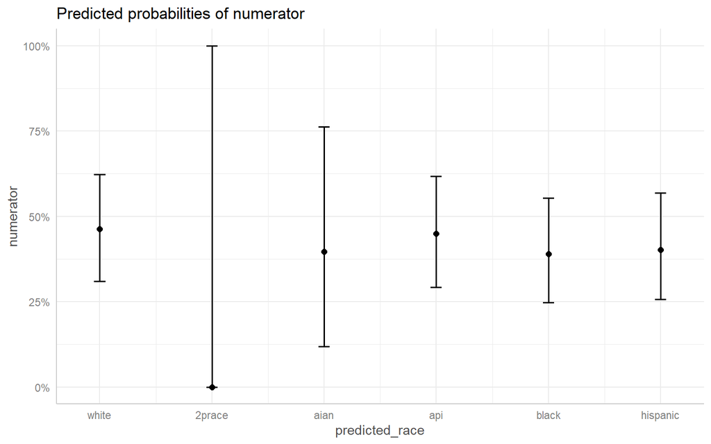

```r
me2 <- ggpredict(mU.glmer, "predicted_race")
plot(me2)
```

```r
me2 <- ggpredict(mU.glmer, "adi_natrank")
```

```
## Data were 'prettified'. Consider using `terms="adi_natrank [all]"` to get smooth plots.
```

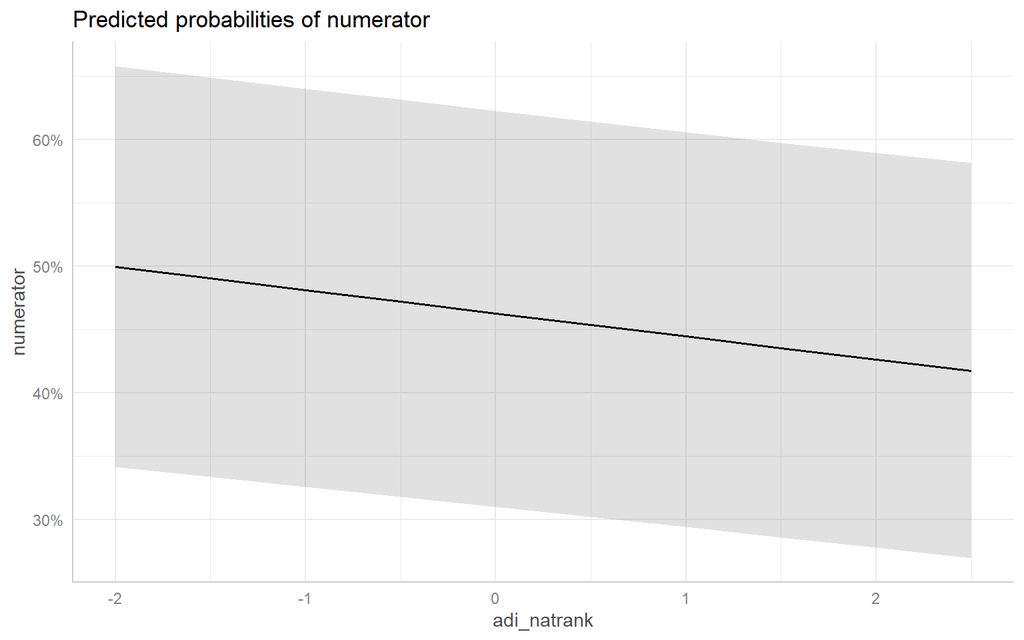

```r
plot(me2)
```

```r
exp(coef(summary(mU.glmer))[ , "Estimate"])
```

```
##            (Intercept)   predicted_race2prace     predicted_raceaian
##           8.635631e-01           2.771703e-06           7.611274e-01
##      predicted_raceapi    predicted_raceblack predicted_racehispanic
##           9.479658e-01           7.407664e-01           7.819498e-01
##             genderMALE          genderUNKNOWN                    age
##           9.985771e-01           1.029604e+05           1.821619e+00
##            adi_natrank
##           9.287740e-01
```

#### method 3 - Bayesian MEMs

```r
mU.bayes <- bglmer(numerator ~  predicted_race +
                     gender +
                     age +
                     adi_natrank +
                     (1|member_number) +
                     (1|ebm_measure_label),
                family = binomial(link="logit"),
                data = under.df,
                control=glmerControl(optimizer = "bobyqa"))
summary(mU.bayes)
```

```
## Cov prior  : member_number ~ wishart(df = 3.5, scale = Inf, posterior.scale = cov, common.scale = TRUE)
##            : ebm_measure_label ~ wishart(df = 3.5, scale = Inf, posterior.scale = cov, common.scale = TRUE)
## Prior dev  : 1.5292
##
## Generalized linear mixed model fit by maximum likelihood (Laplace
##   Approximation) [bglmerMod]
##  Family: binomial  ( logit )
## Formula: numerator ~ predicted_race + gender + age + adi_natrank + (1 |
##     member_number) + (1 | ebm_measure_label)
##    Data: under.df
## Control: glmerControl(optimizer = "bobyqa")
##
##      AIC      BIC   logLik deviance df.resid
##  13108.7  13196.5  -6542.4  13084.7    11091
##
## Scaled residuals:
##     Min      1Q  Median      3Q     Max
## -2.6673 -0.7287  0.4962  0.6330  3.2241
##
## Random effects:
##  Groups            Name        Variance Std.Dev.
##  member_number     (Intercept) 0.2593   0.5092
##  ebm_measure_label (Intercept) 1.3912   1.1795
## Number of obs: 11103, groups:  member_number, 9142; ebm_measure_label, 11
##
## Fixed effects:
##                          Estimate Std. Error z value Pr(>|z|)
## (Intercept)             -0.149020   0.358754  -0.415 0.677862
## predicted_race2prace   -12.783563 352.492856  -0.036 0.971070
## predicted_raceaian      -0.272851   0.736449  -0.370 0.711014
## predicted_raceapi       -0.053773   0.111258  -0.483 0.628870
## predicted_raceblack     -0.300823   0.081685  -3.683 0.000231 ***
## predicted_racehispanic  -0.246771   0.085690  -2.880 0.003979 **
## genderMALE              -0.001521   0.050475  -0.030 0.975965
## genderUNKNOWN           11.538333 375.204496   0.031 0.975467
## age                      0.601616   0.067033   8.975  < 2e-16 ***
## adi_natrank             -0.074342   0.023822  -3.121 0.001804 **
## ---
## Signif. codes:  0 '***' 0.001 '**' 0.01 '*' 0.05 '.' 0.1 ' ' 1
##
```

[output cut: 9 more lines]

```
## age          0.027  0.000 -0.009      0.025     -0.001      0.021     -0.017
## adi_natrank  0.012  0.000 -0.038      0.099     -0.268     -0.098      0.068
##             gUNKNO age
## prdctd_rc2p
## predctd_rcn
## predctd_rcp
## prdctd_rcbl
## prdctd_rchs
## genderMALE
## gndrUNKNOWN
## age          0.000
## adi_natrank  0.000  0.001
## optimizer (bobyqa) convergence code: 0 (OK)
## unable to evaluate scaled gradient
## Model failed to converge: degenerate  Hessian with 1 negative eigenvalues
```

### Test for significance of variables

#### test random effect

```r
mU.glmer <- glmer(numerator ~  predicted_race +
                    gender +
                    age +
                    adi_natrank +
                    (1|member_number) +
                    (1|ebm_measure_label),
                family = binomial(link="logit"),
                data = under.df)

mU.glmer.r <- glmer(numerator ~  predicted_race +
                      gender +
                      age +
                      adi_natrank +
                      (1|member_number),
                family = binomial(link="logit"),
                data = under.df)

anova(mU.glmer, mU.glmer.r)
```

```
## Data: under.df
## Models:
## mU.glmer.r: numerator ~ predicted_race + gender + age + adi_natrank + (1 | member_number)
## mU.glmer: numerator ~ predicted_race + gender + age + adi_natrank + (1 | member_number) + (1 | ebm_measure_label)
##            npar   AIC   BIC  logLik deviance  Chisq Df Pr(>Chisq)
## mU.glmer.r   11 14712 14793 -7345.1    14690
## mU.glmer     12 13109 13196 -6542.3    13085 1605.7  1  < 2.2e-16 ***
## ---
## Signif. codes:  0 '***' 0.001 '**' 0.01 '*' 0.05 '.' 0.1 ' ' 1
```

Thus, we should include the random effect term: (1|ebm_measure_label)

#### test interactions

```r
# test the effect predicted_race:ndi
mU.glmer <- glmer(numerator ~  predicted_race +
                    gender +
                    age +
                    adi_natrank +
                    (1|member_number) +
                    (1|ebm_measure_label),
                family = binomial(link="logit"),
                data = under.df)

mU.glmer.racendi <- glmer(numerator ~  predicted_race +
                            gender +
                            age +
                            adi_natrank +
                            predicted_race:adi_natrank +
                            (1|member_number) +
                            (1|ebm_measure_label),
                family = binomial(link="logit"),
                data = under.df,
                control = glmerControl(tolPwrss=1e-3))


anova(mU.glmer, mU.glmer.racendi)
```

```
## Data: under.df
## Models:
## mU.glmer: numerator ~ predicted_race + gender + age + adi_natrank + (1 | member_number) + (1 | ebm_measure_label)
## mU.glmer.racendi: numerator ~ predicted_race + gender + age + adi_natrank + predicted_race:adi_natrank + (1 | member_number) + (1 | ebm_measure_label)
##                  npar   AIC   BIC  logLik deviance  Chisq Df Pr(>Chisq)
## mU.glmer           12 13109 13196 -6542.3    13085
## mU.glmer.racendi   17 13109 13233 -6537.4    13075 9.7314  5    0.08321 .
## ---
## Signif. codes:  0 '***' 0.001 '**' 0.01 '*' 0.05 '.' 0.1 ' ' 1
```

No need for the interaction: predicted_race:adi_natrank

```r
# test the effect gender:ndi
mU.glmer <- glmer(numerator ~  predicted_race +
                    gender +
                    age +
                    adi_natrank +
                    (1|member_number) +
                    (1|ebm_measure_label),
                family = binomial(link="logit"),
                data = under.df)

mU.glmer.genderndi <- glmer(numerator ~  predicted_race +
                              gender +
                              age +
                              adi_natrank +
                              gender:adi_natrank +
                              (1|member_number) +
                              (1|ebm_measure_label),
                family = binomial(link="logit"),
                data = under.df)


anova(mU.glmer, mU.glmer.genderndi)
```

```
## Data: under.df
## Models:
## mU.glmer: numerator ~ predicted_race + gender + age + adi_natrank + (1 | member_number) + (1 | ebm_measure_label)
## mU.glmer.genderndi: numerator ~ predicted_race + gender + age + adi_natrank + gender:adi_natrank + (1 | member_number) + (1 | ebm_measure_label)
##                    npar   AIC   BIC  logLik deviance  Chisq Df Pr(>Chisq)
## mU.glmer             12 13109 13196 -6542.3    13085
## mU.glmer.genderndi   14 13109 13212 -6540.7    13081 3.1925  2     0.2027
```

No need for the interaction: gender:adi_natrank for the underuse model

```r
# test the effect age:ndi
mU.glmer <- glmer(numerator ~  predicted_race +
                    gender +
                    age +
                    adi_natrank +
                    (1|member_number) +
                    (1|ebm_measure_label),
                family = binomial(link="logit"),
                data = under.df)

mU.glmer.agendi <- glmer(numerator ~  predicted_race +
                           gender +
                           age +
                           adi_natrank +
                           age:adi_natrank +
                           (1|member_number) +
                           (1|ebm_measure_label),
                family = binomial(link="logit"),
                data = under.df)


anova(mU.glmer, mU.glmer.agendi)
```

```
## Data: under.df
## Models:
## mU.glmer: numerator ~ predicted_race + gender + age + adi_natrank + (1 | member_number) + (1 | ebm_measure_label)
## mU.glmer.agendi: numerator ~ predicted_race + gender + age + adi_natrank + age:adi_natrank + (1 | member_number) + (1 | ebm_measure_label)
##                 npar   AIC   BIC  logLik deviance  Chisq Df Pr(>Chisq)
## mU.glmer          12 13109 13196 -6542.3    13085
## mU.glmer.agendi   13 13110 13206 -6542.2    13084 0.0636  1     0.8009
```

for the underuse model, interaction age:ndi does not appear to be significant.

### goodness-of-fit

Test correlation between ndi and race

```r
model.lm.U <- lm(adi_natrank ~ predicted_race, data = under.df)
summary(model.lm.U)
```

```
##
## Call:
## lm(formula = adi_natrank ~ predicted_race, data = under.df)
##
## Residuals:
##     Min      1Q  Median      3Q     Max
## -2.3097 -0.7717 -0.1277  0.6489  3.2521
##
## Coefficients:
##                        Estimate Std. Error t value Pr(>|t|)
## (Intercept)            -0.08901    0.01004  -8.863  < 2e-16 ***
## predicted_race2prace   -0.08454    0.67064  -0.126      0.9
## predicted_raceaian      1.24499    0.28611   4.352 1.36e-05 ***
## predicted_raceapi      -0.53247    0.04488 -11.864  < 2e-16 ***
## predicted_raceblack     1.01722    0.03279  31.022  < 2e-16 ***
## predicted_racehispanic  0.36679    0.03541  10.358  < 2e-16 ***
## ---
## Signif. codes:  0 '***' 0.001 '**' 0.01 '*' 0.05 '.' 0.1 ' ' 1
##
## Residual standard error: 0.9483 on 11097 degrees of freedom
##   (3655 observations deleted due to missingness)
## Multiple R-squared:  0.1011, Adjusted R-squared:  0.1007
## F-statistic: 249.6 on 5 and 11097 DF,  p-value: < 2.2e-16
```

```r
rsqU <- summary(model.lm.U)$r.squared
rsqU
```

```
## [1] 0.1010945
```

```r
kruskal.test(adi_natrank ~ predicted_race, data = under.df)
```

```
##
##  Kruskal-Wallis rank sum test
##
## data:  adi_natrank by predicted_race
## Kruskal-Wallis chi-squared = 986.73, df = 5, p-value < 2.2e-16
```

```r
r.squaredGLMM(mU.glmer)
```

```
##                   R2m       R2c
## theoretical 0.0838268 0.3615740
## delta       0.0730870 0.3152495
```

Marginal R2 provides the variance explained only by fixed effects and conditional R2 provides the variance explained by the entire model, i.e., both fixed effects and random effects

```r
summary(mU.glmer)$varcor
```

```
##  Groups            Name        Std.Dev.
##  member_number     (Intercept) 0.49442
##  ebm_measure_label (Intercept) 1.08941
```

```r
#fixed + random
lrAcc(mU.glmer, 'numerator')
```

```
## [1] 0.7196253
```

```r
#baseline is the intercept only model: intercept + random
baselineAcc(mU.glmer, 'numerator')
```

```
## [1] 0.598577
```

```r
#fix effects only
lrAcc(m0.glmer, 'numerator', use.ranef=FALSE)
```

```
## [1] 0.6022288
```

```r
r.squaredGLMM(mU.bayes)
```

```
##                    R2m       R2c
## theoretical 0.07960002 0.3870944
## delta       0.06978156 0.3393473
```

```r
lrAcc(mU.bayes, 'numerator')
```

```
## [1] 0.7198955
```

```r
baselineAcc(mU.bayes, 'numerator')
```

```
## [1] 0.598577
```

```r
lrAcc(m0.bayes, 'numerator', use.ranef=FALSE)
```

```
## [1] 0.6010917
```

## Resources and citations:

Julian Faraway (2016): Extending the Linear Models with R

https://www.ssc.wisc.edu/sscc/pubs/MM/MM_DiagInfer.html

http://people.linguistics.mcgill.ca/~morgan/book/mixed-effects-logistic-regression.html#ref-Chung2013likelihood

Marginal R2 provides the variance explained only by fixed effects Conditional R2 provides the variance explained by the entire model, i.e., both fixed effects and random effects. Citation: Nakagawa, S., Schielzeth, H. (2013) A general and simple method for obtaining R² from Generalized Linear Mixed-effects Models. Methods in Ecology and Evolution 4: 133–142